# tt+DM reinterpretation, x-sec investigation

Are decays of the mediator $\phi$ into $t\bar{t}$ for masses above the tt threshold accounted for? There is no visible kink in the limit curve that is making us suspicuous.

```python
import matplotlib.pyplot as plt
import numpy as np

import mplhep as hep
plt.style.use(hep.style.CMS)
```

## Calculating the x-secs

First, calculate x-secs with similar settings as used for the central CMS samples. The MG process looks like this:

```
import model DMsimp_s_spin0
define p = g u c d s b u~ c~ d~ s~ b~
generate p p > xd xd~ t t~ / a z w+ w- @0
```

Here, I don't include an extra parton in the ME to save some time. The model comes from here: [CMS extra model repository](https://cms-project-generators.web.cern.ch/cms-project-generators/)

Couplings and masses are then edited to

```
set param_card MASS 6 172.5
set param_card DECAY 6 auto
set param_card YUKAWA 6 172.5
set param_card MASS  52 1
set param_card MASS  54 500
set param_card DECAY 54 auto
set param_card gSXd  1.0
set param_card gPXd  0.0
set param_card gSd11 1.0
set param_card gSu11 1.0
set param_card gSd22 1.0
set param_card gSu22 1.0
set param_card gSd33 1.0
set param_card gSu33 1.0
set param_card gPd11 0.0
set param_card gPu11 0.0
set param_card gPd22 0.0
set param_card gPu22 0.0
set param_card gPd33 0.0
set param_card gPu33 0.0
set param_card gSg   0.0
set param_card gSh1  0.0
set param_card gSb   0.0
set param_card gSw   0.0
set param_card gPg   0.0
set param_card gPb   0.0
set param_card gPw   0.0
```

Particle 54 corresponds to the mediator, and this mass is scanned. The resulting x-secs are given in xsec_inv.

Note to myself: One needs to be careful that the widths are actually recomputed, which is apparently not done if you just use "launch" again and change one parameter in MG.

```python
xsec_inv = np.array([
    [200, 0.1001],
    [250, 0.05311],
    [300, 0.03296],
    [340, 0.02449],
    [350, 0.02277],
    [360, 0.02075],
    [400, 0.01416],
    [450, 0.009261],
    [500, 0.006427],
])
```

Now I compute the inclusive cross section, $p p \to t \bar{t} \phi$. The mediator is forced to be on-shell here, but that should be fine for this simple check. The results are given in xsec_incl.

```python
xsec_incl = np.array([
    [200, 0.1005],
    [250, 0.05315],
    [300, 0.03322],
    [350, 0.02307],
    [400, 0.01712],
    [450, 0.01315],
    [500, 0.01028],
])
```

One can calculate the ratio $\Gamma_{ratio} = \frac{\Gamma(\phi\to t \bar{t})}{\Gamma(\phi\to \chi \chi)}$ following https://arxiv.org/pdf/1605.09242.pdf

```python
def width_ratio(m_med):
    return (3/2)*((m_med**2-4*172.5**2)/(m_med**2))**(3/2)
```

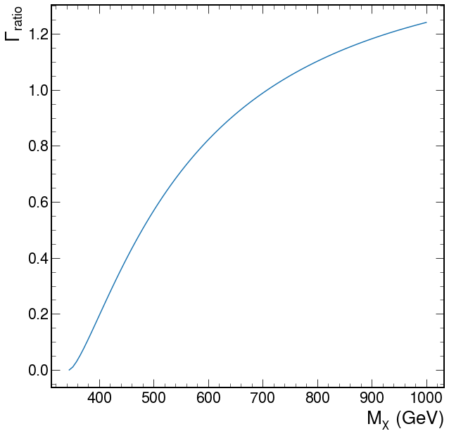

```python
x = np.linspace(345,1000,100)
plt.plot(x,width_ratio(x))

plt.xlabel(r'$M_{\chi}$ (GeV)')
plt.ylabel(r'$\Gamma_{ratio}$')
```

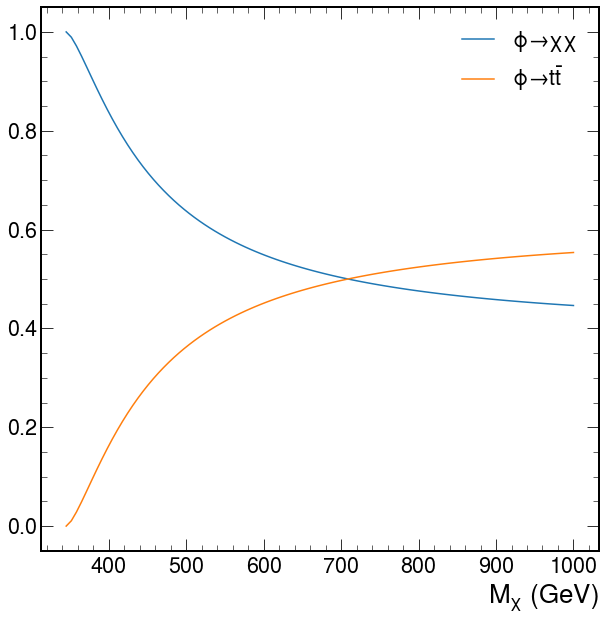

```python
plt.plot(x,1-(width_ratio(x)/(1+width_ratio(x))),
        label=r'$\phi\to \chi \chi$')
plt.plot(x,width_ratio(x)/(1+width_ratio(x)),
        label=r'$\phi\to t \bar{t}$')

plt.xlabel(r'$M_{\chi}$ (GeV)')
plt.legend()
```

## Results

We can compare the x-sec we get from MG directly with the one we get when calculating the inclusive x-sec and the respective branching fraction. From the results we can conclude that MG correctly takes the decay $\phi\to t \bar{t}$ into account.

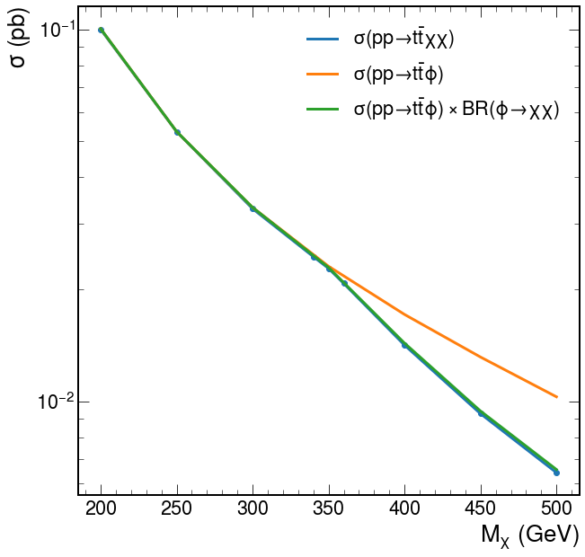

```python
plt.scatter(xsec_inv[:,0], xsec_inv[:,1])

plt.plot(
    xsec_inv[:,0], xsec_inv[:,1],
    label=r'$\sigma(pp\to t\bar{t}\chi \chi)$',
    linewidth=3,
)

plt.plot(
    xsec_incl[:,0], xsec_incl[:,1],
    label=r'$\sigma(pp\to t\bar{t}\phi)$',
    linewidth=3,
)

plt.plot(
    xsec_incl[:,0],
    xsec_incl[:,1]*np.nan_to_num(1-(width_ratio(xsec_incl[:,0])/(1+width_ratio(xsec_incl[:,0]))), nan=1.0, copy=False),
    label=r'$\sigma(pp\to t\bar{t}\phi) \times BR(\phi \to \chi \chi)$',
    linewidth=3,
)

plt.yscale('log')
plt.legend()

plt.xlabel(r'$M_{\chi}$ (GeV)')
plt.ylabel(r'$\sigma$ (pb)')
```

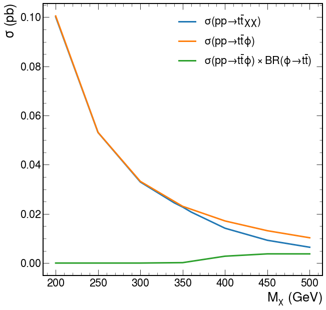

```python
plt.plot(
    xsec_inv[:,0],
    xsec_inv[:,1],
    label=r'$\sigma(pp\to t\bar{t}\chi \chi)$',
    linewidth=3,
)

plt.plot(
    xsec_incl[:,0],
    xsec_incl[:,1],
    label=r'$\sigma(pp\to t\bar{t}\phi)$',
    linewidth=3,
)

plt.plot(
    xsec_incl[:,0],
    np.nan_to_num(xsec_incl[:,1]*((width_ratio(xsec_incl[:,0])/(1+width_ratio(xsec_incl[:,0])))), copy=False),
    label=r'$\sigma(pp\to t\bar{t}\phi) \times BR(\phi \to t\bar{t})$',
    linewidth=3,
)

plt.legend()

plt.xlabel(r'$M_{\chi}$ (GeV)')
plt.ylabel(r'$\sigma$ (pb)')
```